# Final Project: Generalized Social Trust in the U.S. 1972-2012

> Course: PSYC798W_Winter2015: R Programming for Behavioral Sciences  
> Professor: Dr. Scott Jackson  
> Student: Hsiang-Yuan Ho

## Data Clean-up

I use General Social Survey (GSS) which has interviewed a nationally representative sub-population every one or two years since 1972 in the U.S. It documents from demographic information to public opinion and political attitudes. For this project, I extract smaples asked of social trust questions, leading to a total of 34379 cases remained in data set.

Data was collected in 1972, 1973, 1975, 1976, 1978, 1980, 1983, 1984, 1986, 1987, 1988, 1989, 1990, 1991, 1993, 1994, 1996, 1998, 2000, 2002, 2004, 2006, 2008, 2010, 2012.

## Descriptive Statistics

**Demographics**

Participants are at least 18 years old with a mean age of 46. About 44.57% are men. The majority is white (82.11%) and blacks account for 13.37%. Most participants completed high school (77.24%), but only 20.52% have attained a bachelor’s degree or higher. More than half (54.6%) of participants are currently married, and another 20.17% are never married.

**Social trust components**

I recode values of variables below so that higher scores represent higher degrees of perceived trust.

- Helpful

  Survey question: Would you say that most of the time people try to be helpful, or that they are mostly just looking out for themselves?

| Value | Label |
| --- | --- |
| 1 | Just look out for themselves |
| 2 | Depends |
| 3 | Try to be helpful |
| *2.04* | *Average score* |

- Fair

  Survey question: Do you think most people would try to take advantage of you if they got a chance, or would they try to be fair?

| Value | Label |
| --- | --- |
| 1 | Would take advantage of you |
| 2 | Depends |
| 3 | Would try to be fair |
| *2.19* | *Average score* |

- Trust

  Survey question: Generally speaking, would you say that most people can be trusted or that you can’t be too careful in dealing with people?

| Value | Label |
| --- | --- |
| 1 | Can’t be too careful |
| 2 | Depends |
| 3 | Most people can be trusted |
| *1.81* | *Average score* |

## Analyses

In this project, I ask the following questions: 1) How has generalized social trust in the U.S. changed during the four decades? 2) Does social trust vary by gender, age, education, and racial groups? 3) If so, how have these group differences changed with time? 4) How do gender, age, education, and race affect social trust?

**1) Trend of social trust**

- Generalized social trust

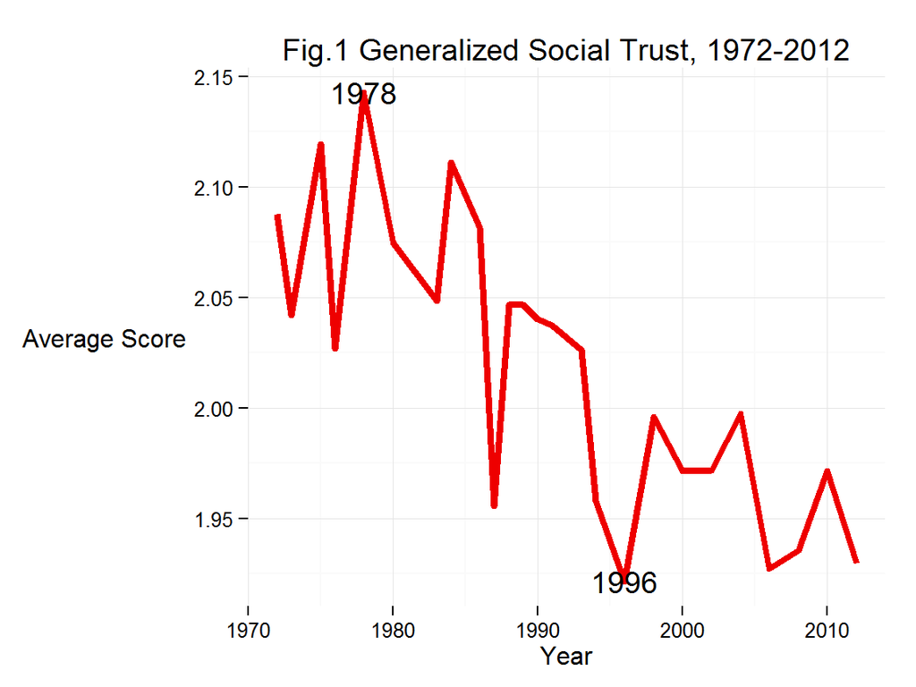

- Helpful, Fair, and Trust items

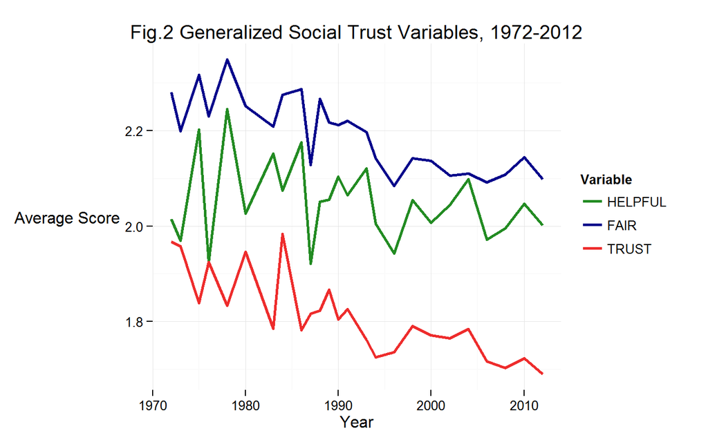

> According to Figure 1, social trust in the U.S. has declined during the past four decades and reached another low level in recent years. Broken down by three component variables, though perceived helpfulness remained on average stable, the overall decrease of social trust has been driven by both fairness and trustworthiness.

**2) Demographic differences in social trust**

- Age
  - correlation test

```
## [1] "r is = 0.1524 p < .05, positive correlation!"
```

- Gender
  - men is coded “1” and women “2”
  - t-test

```
## [1] "p < .05, significant result!"
```

- Race
  - white is coded “1”, black “2”, and other races “3”
  - anova test

```
## [1] "p < .05, significant result!"
```

- Education
  - using self-reported educational years
  - correlation test

```
## [1] "r is = 0.2296 p < .05, positive correlation!"
```

> In short, participants who report higher social trust are more likely to be female, older, white, and have more education.

**3) Trend of social trust by demographics**

- Age

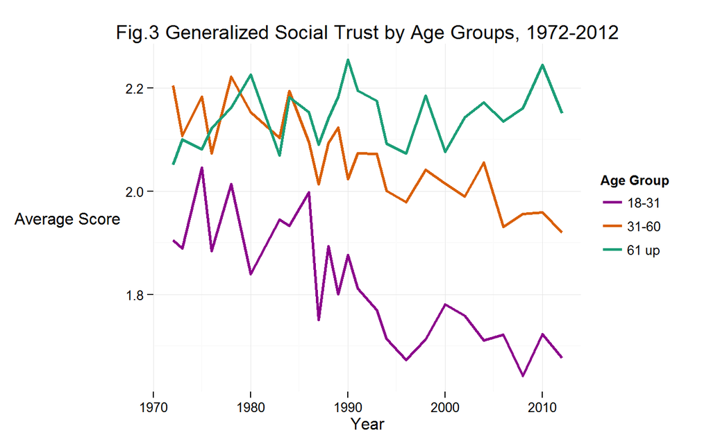

> The young generations have always had the lowest social trust among three age groups and seem to have reached a bottom low in the past dacade. While scores of the two younger age groups gradually decline, the seniors show slowly rising social trust.
- Gender

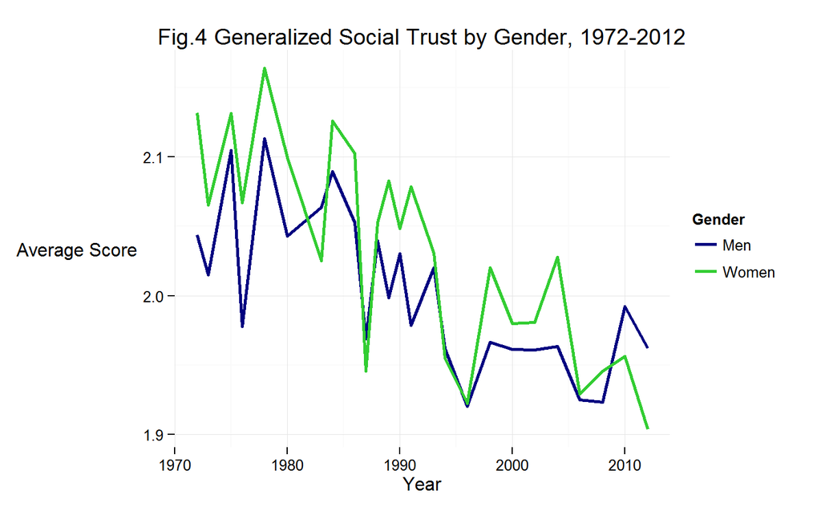

> Though both showing a decreasing trend, women in general perceive higher social trust than men.
- Race

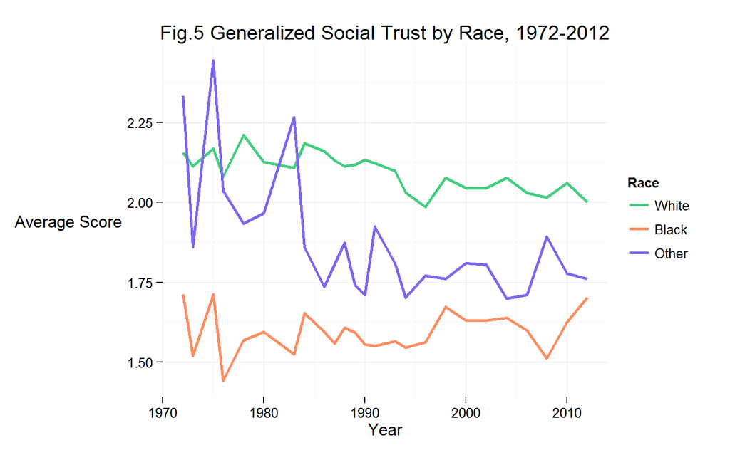

> On average, perceived social trust has stayed stable for Whites and Blacks with the latter displaying the least trust. What’s interesting is other races have demonstrated a dramatic decrease over the four decades from scoring the highest to converging with Blacks at the bottom.
- Education

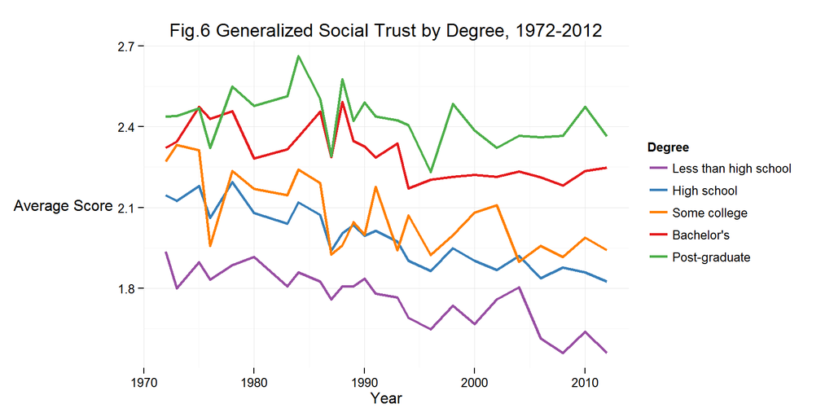

> Compared to the two highest education groups, participants who finished some college or below show a clearer decrease of social trust.

**4) Demographic effects on social trust**

```
##
## Table1: Regression Coefficients Estimating Demographic Effects on Generalized Social Trust
## =============================================
##                       Dependent variable:
##                   ---------------------------
##                       Social Trust Scale
## ---------------------------------------------
## Age                        0.008***
##                            (0.0002)
##
## Female                     0.039***
##                             (0.007)
##
## Non-White                  -0.194***
##                             (0.007)
##
## Educational years          0.067***
##                             (0.001)
##
## Marital Status             -0.024***
##                             (0.002)
##
## Year                       -0.007***
##                            (0.0003)
##
## Constant                   15.282***
##                             (0.656)
##
## ---------------------------------------------
## Observations                34,379
## R2                           0.137
## Adjusted R2                  0.137
## =============================================
## Note:             *p<0.1; **p<0.05; ***p<0.01
```

```
##                   Table2: Relative Importance (Sum to 100%)
## Age                                                  0.1936
## Female                                               0.0037
## Non-White                                            0.2091
## Educational years                                    0.4663
## Marital Status                                       0.0690
## Year                                                 0.0584
```

> As Table 1 shows, controling for cohort effect and marital status, age, gender, race, and education all have significant impact on social trust. As significance tests indicated earlier, older ages, being female, being white, and more educations all contribute to higher social trust.  
> The second table displays percentage of relative importance of each predictor. Among all the four variables discussed, years of education weighs the most.